# Introduction to R Notebooks

# Getting Started with R Notebooks

R Notebooks are interactive documents that combine code, output, and narrative text. They’re perfect for data analysis, teaching, and sharing reproducible research.

## What Makes R Notebooks Special?

Unlike traditional R scripts, notebooks: - Display code output inline - Support rich text formatting with Markdown - Allow for interactive exploration - Can be executed chunk by chunk - Export to HTML, PDF, or Word formats

Let’s explore the key features!

## Creating and Running Code Chunks

Code chunks are enclosed in triple backticks with `{r}` to indicate R code:

```r
# This is an R code chunk
x <- 5
y <- 10
x + y
```

```
[1] 15
```

The output appears directly below the code. To run a chunk: - Click the green “play” button in the top-right corner of the chunk - Use the keyboard shortcut Ctrl+Shift+Enter (Cmd+Shift+Enter on Mac) - To run a single line, position your cursor on that line and press Ctrl+Enter

## Chunk Options

You can customize how chunks behave using options:

```r
# This code is displayed but not executed
this_wont_run <- "example"
```

Common chunk options: - `echo`: Whether to display the code (TRUE/FALSE) - `eval`: Whether to evaluate/run the code (TRUE/FALSE) - `warning`: Whether to show warnings (TRUE/FALSE) - `message`: Whether to show messages (TRUE/FALSE) - `fig.width`, `fig.height`: Control the size of figures

## Creating Visualizations

Visualizations render directly in the notebook:

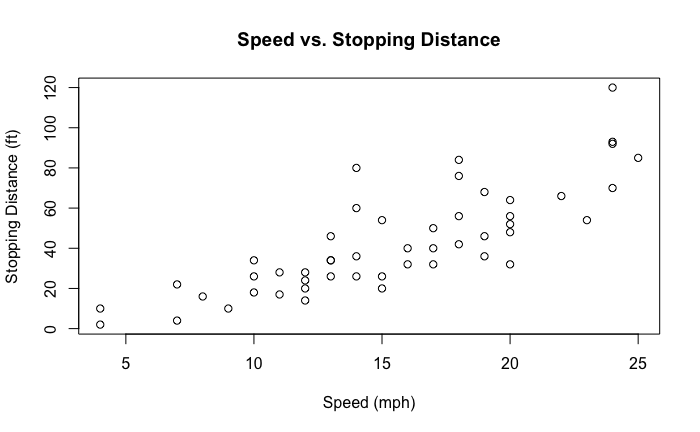

```r
# Basic plot example
plot(cars, main = "Speed vs. Stopping Distance",
     xlab = "Speed (mph)", ylab = "Stopping Distance (ft)")
```

And here’s a more advanced example with ggplot2:

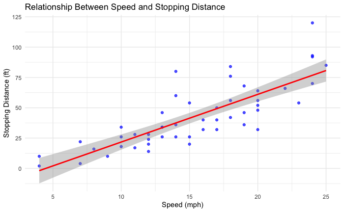

```r
# Load ggplot2 package
library(ggplot2)

# Create a nicer visualization
ggplot(cars, aes(x = speed, y = dist)) +
  geom_point(color = "blue", alpha = 0.7) +
  geom_smooth(method = "lm", se = TRUE, color = "red") +
  labs(title = "Relationship Between Speed and Stopping Distance",
       x = "Speed (mph)",
       y = "Stopping Distance (ft)") +
  theme_minimal()
```

## Inline R Code

You can include R output directly within text using backticks with `r`:

The average stopping distance in the cars dataset is 43 feet, and the average speed is 15.4 mph.

## Interactive Tables

Tables are a great way to display data:

```r
# Basic table
head(mtcars[, 1:5])
```

|  | mpg | cyl | disp | hp | drat |
| --- | --- | --- | --- | --- | --- |
| Mazda RX4 | 21.0 | 6 | 160 | 110 | 3.90 |
| Mazda RX4 Wag | 21.0 | 6 | 160 | 110 | 3.90 |
| Datsun 710 | 22.8 | 4 | 108 | 93 | 3.85 |
| Hornet 4 Drive | 21.4 | 6 | 258 | 110 | 3.08 |
| Hornet Sportabout | 18.7 | 8 | 360 | 175 | 3.15 |
| Valiant | 18.1 | 6 | 225 | 105 | 2.76 |

For more attractive tables, try the kable function from knitr:

```r
library(knitr)
kable(head(mtcars[, 1:5]), caption = "First 6 rows of mtcars dataset")
```

First 6 rows of mtcars dataset

|  | mpg | cyl | disp | hp | drat |
| --- | --- | --- | --- | --- | --- |
| Mazda RX4 | 21.0 | 6 | 160 | 110 | 3.90 |
| Mazda RX4 Wag | 21.0 | 6 | 160 | 110 | 3.90 |
| Datsun 710 | 22.8 | 4 | 108 | 93 | 3.85 |
| Hornet 4 Drive | 21.4 | 6 | 258 | 110 | 3.08 |
| Hornet Sportabout | 18.7 | 8 | 360 | 175 | 3.15 |
| Valiant | 18.1 | 6 | 225 | 105 | 2.76 |

## Working with Data

Here’s a simple data analysis workflow:

```r
# Load and examine data
data(iris)
str(iris)
```

```
'data.frame':   150 obs. of  5 variables:
 $ Sepal.Length: num  5.1 4.9 4.7 4.6 5 5.4 4.6 5 4.4 4.9 ...
 $ Sepal.Width : num  3.5 3 3.2 3.1 3.6 3.9 3.4 3.4 2.9 3.1 ...
 $ Petal.Length: num  1.4 1.4 1.3 1.5 1.4 1.7 1.4 1.5 1.4 1.5 ...
 $ Petal.Width : num  0.2 0.2 0.2 0.2 0.2 0.4 0.3 0.2 0.2 0.1 ...
 $ Species     : Factor w/ 3 levels "setosa","versicolor",..: 1 1 1 1 1 1 1 1 1 1 ...
```

```r
# Basic summary statistics
summary(iris$Sepal.Length)
```

```
   Min. 1st Qu.  Median    Mean 3rd Qu.    Max.
  4.300   5.100   5.800   5.843   6.400   7.900
```

```r
# Group-level statistics
aggregate(Sepal.Length ~ Species, data = iris, FUN = function(x) {
  c(mean = mean(x), sd = sd(x), min = min(x), max = max(x))
})
```

[output not shown]

## Mathematical Expressions and LaTeX

R Notebooks fully support LaTeX for mathematical notation, making them ideal for statistical, scientific, and mathematical content. LaTeX can be used in two ways:

### Inline Math Expressions